# COMPSCIX 415.2 Homework 5/Midterm

##### ANSWER:

The highest number of sales in txhousing data was recorded in July 2015 in the city of Houston. data.

```r
maxsale <- txhousing %>% arrange(desc(sales))
maxsale
```

```
## # A tibble: 8,602 x 9
##    city     year month sales     volume median listings inventory  date
##    <chr>   <int> <int> <dbl>      <dbl>  <dbl>    <dbl>     <dbl> <dbl>
##  1 Houston  2015     7  8945 2568156780 217600    23875      3.40  2016
##  2 Houston  2006     6  8628 1795898108 155200    36281      5.60  2006
##  3 Houston  2013     7  8468 2168720825 187800    21497      3.30  2014
##  4 Houston  2015     6  8449 2490238594 222400    22311      3.20  2015
##  5 Houston  2013     5  8439 2121508529 186100    20526      3.30  2013
##  6 Houston  2014     6  8391 2342443127 211200    19725      2.90  2014
##  7 Houston  2014     7  8391 2278932511 199700    20214      3.00  2014
##  8 Houston  2014     8  8167 2195184825 202400    20007      2.90  2015
##  9 Houston  2013     8  8155 2083377894 186700    21366      3.30  2014
## 10 Houston  2006     5  8040 1602621368 151200    35398      5.50  2006
## # ... with 8,592 more rows
```

*4. What kind of relationship do you think exists between the number of listings and the number of sales? Check your assumption and show your work.*

##### ANSWER:

The relationship between the number of listings and the number of sales is a positive correlation.

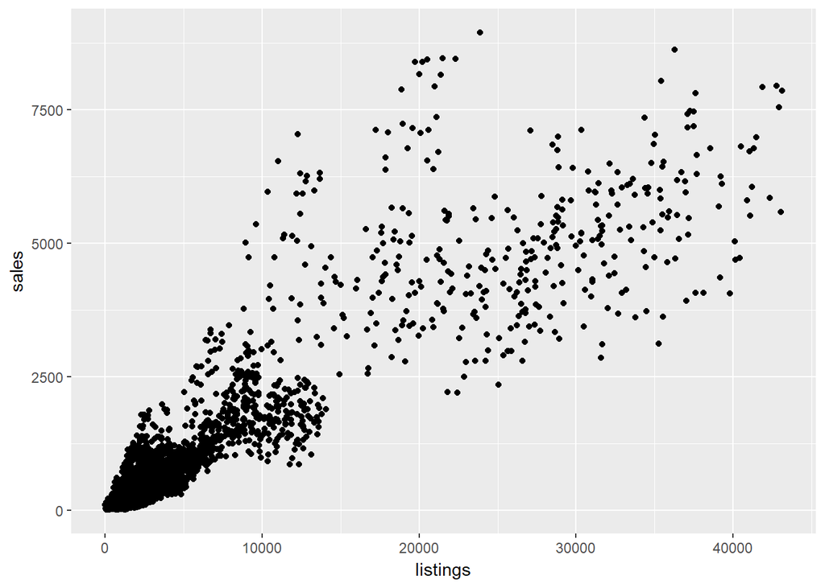

```r
ggplot(data = txhousing) +
  geom_point(mapping = aes(x = listings, y = sales))
```

*5. What proportion of sales is missing for each city?*

##### ANSWER:

Variable proportion_missing in the vector Q_7_5_Answer answers this question.

```r
grouped_city <- txhousing %>%group_by(city) %>% summarise(sales_count = n())


filtered_city <- txhousing %>% filter (!is.na(sales)) %>% group_by(city) %>%
  summarise(filtered_sales_count = n())

city_joined <- grouped_city %>% inner_join(filtered_city, by =c("city" ="city"))

Q_7_5_Answer <- city_joined %>% mutate( missing_sales = sales_count - filtered_sales_count, proportion_missing = missing_sales / sales_count)
Q_7_5_Answer
```

```
## # A tibble: 46 x 5
##    city       sales_count filtered_sales_c~ missing_sales proportion_miss~
##    <chr>            <int>             <int>         <int>            <dbl>
##  1 Abilene            187               187             0           0
##  2 Amarillo           187               187             0           0
##  3 Arlington          187               187             0           0
##  4 Austin             187               187             0           0
##  5 Bay Area           187               187             0           0
##  6 Beaumont           187               187             0           0
##  7 Brazoria ~         187               173            14           0.0749
##  8 Brownsvil~         187               185             2           0.0107
##  9 Bryan-Col~         187               187             0           0
## 10 Collin Co~         187               187             0           0
## # ... with 36 more rows
```

##### ANSWER:

```r
sales_gt_500 <- filter(txhousing,sales > 500)
sales_gt_500
```

```
## # A tibble: 1,883 x 9
##    city       year month sales   volume median listings inventory  date
##    <chr>     <int> <int> <dbl>    <dbl>  <dbl>    <dbl>     <dbl> <dbl>
##  1 Arlington  2000     8   507 60875199 103400     1417      3.50  2001
##  2 Arlington  2001     5   536 69878959 114400     1592      3.70  2001
##  3 Arlington  2001     6   534 67744182 108500     1627      3.80  2001
##  4 Arlington  2001     8   505 65080743 113600     1616      3.70  2002
##  5 Arlington  2002     5   503 67240236 116100     1741      3.90  2002
##  6 Arlington  2002     7   509 66954143 119100     1925      4.40  2002
##  7 Arlington  2003     5   502 67131982 118000     2544      5.90  2003
##  8 Arlington  2003     7   524 73194692 123500     2799      6.50  2004
##  9 Arlington  2003     8   531 72397143 123900     2801      6.40  2004
## 10 Arlington  2004     5   527 72401436 118300     2922      6.50  2004
## # ... with 1,873 more rows
```

```r
Q_7_6_answer <- sales_gt_500 %>% group_by(city)
Q_7_6_answer
```

```
## # A tibble: 1,883 x 9
## # Groups:   city [14]
##    city       year month sales   volume median listings inventory  date
##    <chr>     <int> <int> <dbl>    <dbl>  <dbl>    <dbl>     <dbl> <dbl>
##  1 Arlington  2000     8   507 60875199 103400     1417      3.50  2001
##  2 Arlington  2001     5   536 69878959 114400     1592      3.70  2001
##  3 Arlington  2001     6   534 67744182 108500     1627      3.80  2001
##  4 Arlington  2001     8   505 65080743 113600     1616      3.70  2002
##  5 Arlington  2002     5   503 67240236 116100     1741      3.90  2002
##  6 Arlington  2002     7   509 66954143 119100     1925      4.40  2002
##  7 Arlington  2003     5   502 67131982 118000     2544      5.90  2003
##  8 Arlington  2003     7   524 73194692 123500     2799      6.50  2004
##  9 Arlington  2003     8   531 72397143 123900     2801      6.40  2004
## 10 Arlington  2004     5   527 72401436 118300     2922      6.50  2004
## # ... with 1,873 more rows
```

```r
by_city <- group_by(txhousing,city)
summarise(by_city,
  sales_count = n()) %>% mutate(sales_count)
```

```
## # A tibble: 46 x 2
##    city                  sales_count
##    <chr>                       <int>
##  1 Abilene                       187
##  2 Amarillo                      187
##  3 Arlington                     187
##  4 Austin                        187
##  5 Bay Area                      187
##  6 Beaumont                      187
##  7 Brazoria County               187
##  8 Brownsville                   187
##  9 Bryan-College Station         187
## 10 Collin County                 187
## # ... with 36 more rows
```

```r
by_city2 <- filter(txhousing,!is.na(sales)) %>% group_by(city)
summarise (by_city2, count2= n(), missing_sales = 187 - count2, prop_missing = missing_sales / count2)
```

```
## # A tibble: 46 x 4
##    city                  count2 missing_sales prop_missing
##    <chr>                  <int>         <dbl>        <dbl>
##  1 Abilene                  187          0          0
##  2 Amarillo                 187          0          0
##  3 Arlington                187          0          0
##  4 Austin                   187          0          0
##  5 Bay Area                 187          0          0
##  6 Beaumont                 187          0          0
##  7 Brazoria County          173         14.0        0.0809
##  8 Brownsville              185          2.00       0.0108
##  9 Bryan-College Station    187          0          0
## 10 Collin County            187          0          0
## # ... with 36 more rows
```

*6. Looking at only the cities and months with greater than 500 sales: ◦Are the distributions of the median sales price (column name median), when grouped by city, different? The same? Show your work.* ◦Any cities that stand out that you’d want to investigate further? ◦Why might we want to filter out all cities and months with sales less than 500?

```r
sales_gt_500 <- filter(txhousing,sales > 500)
sales_gt_500
```

```
## # A tibble: 1,883 x 9
##    city       year month sales   volume median listings inventory  date
##    <chr>     <int> <int> <dbl>    <dbl>  <dbl>    <dbl>     <dbl> <dbl>
##  1 Arlington  2000     8   507 60875199 103400     1417      3.50  2001
##  2 Arlington  2001     5   536 69878959 114400     1592      3.70  2001
##  3 Arlington  2001     6   534 67744182 108500     1627      3.80  2001
##  4 Arlington  2001     8   505 65080743 113600     1616      3.70  2002
##  5 Arlington  2002     5   503 67240236 116100     1741      3.90  2002
##  6 Arlington  2002     7   509 66954143 119100     1925      4.40  2002
##  7 Arlington  2003     5   502 67131982 118000     2544      5.90  2003
##  8 Arlington  2003     7   524 73194692 123500     2799      6.50  2004
##  9 Arlington  2003     8   531 72397143 123900     2801      6.40  2004
## 10 Arlington  2004     5   527 72401436 118300     2922      6.50  2004
## # ... with 1,873 more rows
```

```r
Q6_answer <- sales_gt_500 %>% group_by(city)
Q6_answer
```

```
## # A tibble: 1,883 x 9
## # Groups:   city [14]
##    city       year month sales   volume median listings inventory  date
##    <chr>     <int> <int> <dbl>    <dbl>  <dbl>    <dbl>     <dbl> <dbl>
##  1 Arlington  2000     8   507 60875199 103400     1417      3.50  2001
##  2 Arlington  2001     5   536 69878959 114400     1592      3.70  2001
##  3 Arlington  2001     6   534 67744182 108500     1627      3.80  2001
##  4 Arlington  2001     8   505 65080743 113600     1616      3.70  2002
##  5 Arlington  2002     5   503 67240236 116100     1741      3.90  2002
##  6 Arlington  2002     7   509 66954143 119100     1925      4.40  2002
##  7 Arlington  2003     5   502 67131982 118000     2544      5.90  2003
##  8 Arlington  2003     7   524 73194692 123500     2799      6.50  2004
##  9 Arlington  2003     8   531 72397143 123900     2801      6.40  2004
## 10 Arlington  2004     5   527 72401436 118300     2922      6.50  2004
## # ... with 1,873 more rows
```

# Git and Github (1.5 points)

*To demonstrate your use of git and Github, at the top of your document put a hyperlink to your Github repository.*